# Ćwiczenia 8

## Zadanie 1

Tak, jest to możliwe, nawet dla jednej komponenty. Może się to wydarzyć, gdy pewna komponenta posiada duży zakres liczbowy i dominuje inne.

Oznacza to, że wszystkie zmienne można zapisać jako transformację liniową jednej z nich, co jest dość ekstremalnym przypadkiem zależności liniowej. Wszystkie główne komponenty zbioru danych stanowią razem podstawę przestrzeni wektorowej, na którą składają się oryginalne zmienne.

## Zadanie 2

```python
import pandas as pd
import numpy as np
import matplotlib.pyplot as plt
from sklearn import datasets
from sklearn.decomposition import PCA
from sklearn.preprocessing import StandardScaler
from sklearn.datasets import fetch_lfw_people
```

```python
iris = datasets.load_iris()

X = iris.data
Y = iris.target

#Standarization

X_std = StandardScaler().fit_transform(X)

#PCA

pca = PCA(n_components = None)
X_pca = pca.fit_transform(X_std)
```

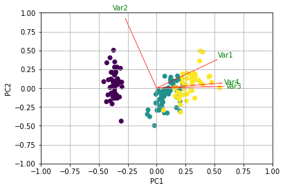

```python
def PCA_plot(score, coeff, labels=None):
    x = score[:,0]
    y = score[:,1]
    n = coeff.shape[0]
    scalex = 1.0/(x.max() - x.min())
    scaley = 1.0/(y.max() - y.min())
    plt.scatter(x * scalex, y * scaley, c = Y)
    for i in range(n):
        plt.arrow(0, 0, coeff[i,0], coeff[i,1], color = 'r', alpha = 0.5)
        if labels is None:
            plt.text(coeff[i,0] * 1.15, coeff[i,1] * 1.15, "Var" + str(i+1), color = 'g', ha = 'center', va = 'center')
        else:
            plt.text(coeff[i,0] * 1.15, coeff[i,1] * 1.15, labels[i], color = 'g', ha = 'center', va = 'center')

plt.xlim(-1,1)
plt.ylim(-1,1)
plt.xlabel("PC{}".format(1))
plt.ylabel("PC{}".format(2))
plt.grid()

PCA_plot(X_pca[:,0:2],np.transpose(pca.components_[0:2, :]))
plt.show()
```

```python
print(abs( pca.components_ ))
```

```
[[0.52106591 0.26934744 0.5804131  0.56485654]
 [0.37741762 0.92329566 0.02449161 0.06694199]
 [0.71956635 0.24438178 0.14212637 0.63427274]
 [0.26128628 0.12350962 0.80144925 0.52359713]]
```

```python
iris.feature_names
```

```
['sepal length (cm)',
 'sepal width (cm)',
 'petal length (cm)',
 'petal width (cm)']
```

Cechy 1, 3 oraz 4 są najbardziej istotne, a więc: długość działki kielicha, długość i szerokość płatków.

```python
var = pca.explained_variance_ratio_
print(var)
```

```
[0.72962445 0.22850762 0.03668922 0.00517871]
```

```python
second = sum(var[:2])
third = sum(var[:3])
fourth = sum(var[:4])
fifth = sum(var[:5])
print('Dwie pierwsze komponenty objaśniają', second, '% wariancji')
print('Trzy pierwsze komponenty objaśniają', third, '% wariancji')
print('Cztery pierwsze komponenty objaśniają', fourth, '% wariancji')
```

```
Dwie pierwsze komponenty objaśniają 0.9581320720000164 % wariancji
Trzy pierwsze komponenty objaśniają 0.9948212908928451 % wariancji
Cztery pierwsze komponenty objaśniają 0.9999999999999999 % wariancji
```

Uważam, że pierwsze dwie komponenty dostatecznie dobrze opisują dane.

## Zadanie 3

```python
lfw = fetch_lfw_people(min_faces_per_person = 60)
pca = PCA(n_components = 150, whiten = True, random_state = 42)

X_pca2 = pca.fit_transform(lfw.data)
var2 = sum(pca.explained_variance_ratio_)
print('Dane komponenty opisują', var2, '% wariancji')
```

```
Dane komponenty opisują 0.9457054856175091 % wariancji
```

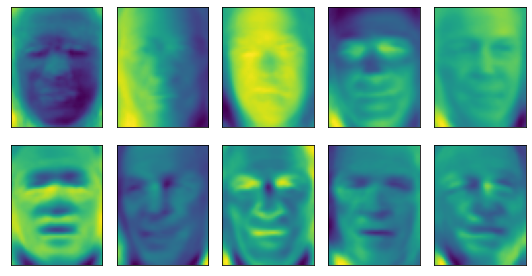

```python
def show_faces(images, n_row=2, n_col=5):
    plt.figure(figsize=(1.5 * n_col, 2.2 * n_row))
    plt.subplots_adjust(0.6, 0.5, 1.5, 1.5)
    for i in range(n_row * n_col):
        plt.subplot(n_row, n_col, i + 1)
        plt.imshow(pca.components_[i].reshape(62,47))
        plt.xticks(())
        plt.yticks(())
    plt.tight_layout()
    plt.show()

show_faces(np.concatenate((X_pca2[:9]),axis=0))
```

Powyższe twarze to wizualizacja wektorów, reprezentujących maksymalną wariancję danych.

## Zadanie 4

Independent Component Analysis (ICA) to nienadzorowany algorytm ML, który służy do znajdowania niezależnych grup kolumn w danych.

Jest on podobny do PCA, przy czym w PCA staramy się znaleźć liniowe kombinacje zmiennych jako głównych składowych, pomiędzy którymi nie ma zależności. W ICA szukamy natomiast liniowych kombinacji zmiennych jako niezależnych składowych. Nie ma tu korelcji pomiędzy dowolnymi dwoma składnikami.

Algorytm ICA stosuje równanie $X= MD$, gdzie:

$X$ - macierz niezależnych składników $M$ - matryca mieszania $D$ - oryginalne dane

Algorytm ten znajduje niezależne składowe mnożąc macierz miksującą przez oryginalne dane. Jego celem jest znalezienie takiej Matrycy mieszanki „M” pomnożonej przez dane „D”, aby wszystkie kolumny w „X” były od siebie niezależne.